# t-Reconciliation

# Introduction

This vignette shows how to perform *t-student reconciliation*. The key idea is to place a prior distribution on the covariance matrix of the residuals, thereby accounting for its uncertainty.

By choosing the Inverse-Wishart distribution as the prior, the reconciliation can be computed in closed form. As a result, the reconciled predictive distribution becomes a multivariate t-distribution.

# Installation

The packages needed :

```r
install.packages('forecast', dependencies = TRUE)
install.packages('bayesRecon', dependencies = TRUE)
install.packages('nloptr', dependencies = TRUE)
install.packages('ggplot2', dependencies = TRUE)
install.packages('dplyr', dependencies = TRUE)
install.packages('tidyr', dependencies = TRUE)
```

Load the packages:

```r
library(forecast) #for base forecasts
library(bayesRecon) #for schafer and strimmer shrinkage
library(nloptr) #for LOO
```

```r
library(mvtnorm) #for representing the distribution
# for plot
library(ggplot2)
library(dplyr)
library(tidyr)
```

# Loading the dataset

The example presented uses monthly Swiss overnight stays data, which are publicly available on the official website of the Swiss Confederation. The data are treated as continuous, and the hierarchical structure is cross-sectional, consisting of two levels: the national total and the division by canton.

The dataset spans the period from January 2005 to January 2025, comprising 241 monthly observations.

The time series exhibit strong seasonality. As an example, we plot the data for the top-level (aggregate) series below.

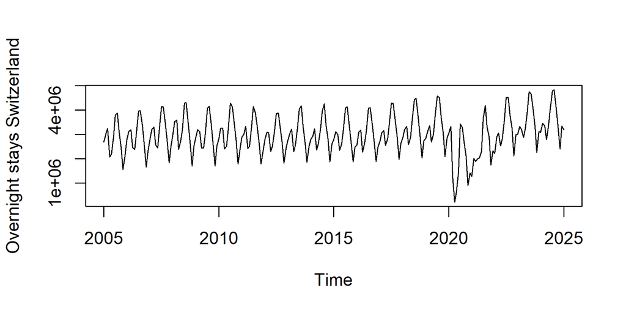

**Figure 1**: Swiss tourism - monthly Swiss overnight stays.

```r
dir_path = dirname(rstudioapi::getSourceEditorContext()$path)

Y = readRDS(paste0(dir_path, "/data/data_Swiss_tourism.RDS"))
cantons = rownames(Y)

Y = ts(t(Y), start = c(2005, 1), frequency = 12)

plot.ts(Y[, 1], xlab = "Time", ylab = "Overnight stays Switzerland", main = NULL)
```

We load the aggregation matrix and set the model parameters. The length of the training set can be selected within the range [26, 240] observations.

```r
A = readRDS(paste0(dir_path, "/data/A_Swiss_tourism.RDS"))

n_b = ncol(A)
n_u = nrow(A)
n = n_b + n_u

S = rbind(A, diag(rep(1, n_b)))

# L = ncol(Y) #This parameter can be chosen differently
L = 46
freq = 12

h = 1

train = window(Y, end = time(Y)[L])
actuals = window(Y, start= time(Y)[L + 1], end = time(Y)[L + h])


check.seasonality = as.logical(apply(Y, 2, function(row) nsdiffs(ts(row, frequency = freq))))
```

# Reconciliation

The base forecasts are generated using the ets() function from the forecast package, which fits exponential smoothing models to each time series.

To address potential instability in the estimation of the residual covariance matrix, particularly when the number of observations is limited, we apply a slight shrinkage to the sample covariance matrix.

```r
##############################Base forecasts#####################################
base_fc = matrix(NA, ncol = h, nrow = n)
res = matrix(NA, ncol = n, nrow = L)
for (i in 1:n){
    models = forecast::ets(ts(train[,i ], frequency = freq), model = "AZZ")
    f = forecast(models, h = h)
    base_fc[i, ] = f$mean
    res[, i] = models$residuals
}

Sigma = crossprod(res)/nrow(res)
Sigmahat = (1 - 10^-4)* Sigma + 10^-4 * diag(diag(Sigma))
```

The Inverse-Wishart distribution used as a prior has two parameters: the degrees of freedom $\nu$, and the scale matrix $\Sigma$.

The prior parameters are computed as follows:

- $\Sigma_0$ is set as the covariance matrix of the residuals obtained from either the naive or seasonal naive forecasting methods, fitted on the training set.  
  If the training set is too short, specifically, shorter than twice the seasonal frequency, only the naive model is used to compute $\Sigma_0$.  
  This is because the seasonal naive method requires at least two seasonal cycles to produce meaningful residuals, and fewer than two observations per season are insufficient to estimate the prior.
- $\nu_0$ is estimated by maximizing the sum of the log of the leave-one-out t-Student predictive distributions.  
  This objective function is referred to as `objective_function` in the code below.

```r
#####################Prior parameters computation###############################
res_naive = matrix(NA, ncol = n, nrow = L)
if (nrow(train) <= 2*freq){
      for (i in 1:n){
          models = forecast::naive(ts(train[,i ]))
          f = forecast(models, h = h)
          res_naive[, i] = models$residuals
      }

    res = res[2:nrow(train), ]
   }else{
        for (i in 1:n){
            models = if (check.seasonality[i]) {
              forecast::snaive(ts(train[,i], frequency = freq))
            }else {
                forecast::naive(ts(train[i,]))}
            f = forecast(models, h = h)
            res_naive[, i] = models$residuals
        }
      res_naive = res_naive[(freq + 1):nrow(train), ]
   }


      naive_mat = schaferStrimmer_cov(res_naive)$shrink_cov


    n_obs = nrow(res_naive)
    n_obs_effective = round(0.1*n_obs)
    inv_sigma_fun = function(x){solve(((naive_mat * (x - n - 1)) + crossprod(res_naive)))}
    log_det_sigma_fun = function(x){sum(log(eigen(((naive_mat * (x - n - 1)) +
                                                 crossprod(res_naive)))$values))}

    log_den_tz_inv_sigma_z_fun = function(l, inv_sigma){log((1 - (((res_naive[l, ])%*%inv_sigma%*%(res_naive[l,])))))}

    objective_function = function(x){
      inv_sigma = inv_sigma_fun(x)

      log_det_sigma = log_det_sigma_fun(x)

      - ((n_obs - n_obs_effective)*(lgamma((x + n_obs)/2)-
                                      lgamma((x + n_obs - n)/2) -
           (log_det_sigma/2)) + ((x + n_obs - 1)/2)*
           sum(sort(vapply(1:n_obs, function(l){log_den_tz_inv_sigma_z_fun(l, inv_sigma)},
                   numeric(1)))[(n_obs_effective + 1):n_obs]))
    }

    initial_guess = n + 2

    lower_bounds = n + 2
    upper_bounds = 5*n

    opts = list("algorithm" = "NLOPT_LN_BOBYQA", "xtol_rel" = 10^-5,
                "maxeval" = 1000)

    results = nloptr(x0 = initial_guess, eval_f = objective_function,
                     lb = lower_bounds, ub = upper_bounds, opts = opts)

    prior.nu = results[[1]]
    prior.psi = (naive_mat)*(prior.nu - n - 1)
```

Since the Inverse-Wishart distribution is conjugate to the Multivariate Gaussian distribution, the posterior distribution of the covariance matrix remains an Inverse-Wishart with updated parameters.

These posterior parameters are then used during the reconciliation phase. The approach is conceptually similar to Gaussian reconciliation via conditioning (Zambon et al. 2024), with two key differences:

- the reconciled distribution is a multivariate t-distribution;
- the incoherence term ($|\mathbf{A} \mathbf{\hat{b}} - \hat{u}|$) appears in the scale parameter, allowing for a more flexible representation of uncertainty.

```r
####################t-Reconciliation##########################################

posterior.psi = (n_obs * Sigmahat) + prior.psi
posterior.nu = prior.nu + n_obs
Psi_u = posterior.psi[1:n_u, 1:n_u]
Psi_b = posterior.psi[(n_u + 1):n, (n_u + 1):n]
Psi_ub = posterior.psi[1:n_u, (n_u + 1):n, drop = FALSE]
mu_u = base_fc[1:n_u]
mu_b = base_fc[(n_u + 1):n]
inco = ((A %*% mu_b) - mu_u)
Q = Psi_u - (Psi_ub %*% t(A)) - (A %*% t(Psi_ub)) + (A %*%
                                                       Psi_b %*% t(A))
invQ = solve(Q)
C = 1 + ((t(inco) %*% invQ %*% inco))
nu_b_tilde = posterior.nu - n_b + 1
mu_b_tilde = mu_b + (t(Psi_ub) - Psi_b %*% t(A)) %*%
  invQ %*% inco
Sigma_b_tilde = as.numeric(C/nu_b_tilde) * (Psi_b - ((t(Psi_ub) - (Psi_b %*% t(A))) %*%
                                                         invQ %*% t(t(Psi_ub) - (Psi_b %*% t(A)))))



#######################t-Student predictive distribution######################
t_Rec_reconciled_mean = S %*% mu_b_tilde
t_Rec_scale_par = S %*% Sigma_b_tilde %*% t(S)
t_Rec_df = nu_b_tilde
```

# Comparison of results

For the selected data window, we compute and compare the predictive densities of the upper-level time series using four different methods: the base forecasts (Base), Bottom-Up reconciliation (BU), Minimum Trace reconciliation (MinT), and t-Reconciliation (t-Rec).

```r
  #BU reconciliation
    BU_reconciled_mean = S %*% base_fc[(n_u + 1):n]
    BU_cov_mat = S %*% Sigmahat[(n_u + 1):n, (n_u + 1):n] %*% t(S)


  #MinT reconciliation with shrunk matrix
    SigmahatS = schaferStrimmer_cov(res)$shrink_cov
    recon_gauss = reconc_gaussian(A, base_fc, SigmahatS)
    MinT_reconciled_mean = S %*% recon_gauss$bottom_reconciled_mean
    MinT_cov_mat = S %*% recon_gauss$bottom_reconciled_covariance %*% t(S)

  #Base forecasts
    Base_reconciled_mean = base_fc
    Base_cov_mat = Sigmahat

  # Index of the upper variable to plot
i_upper <- 1  # change this if a different index is needed

# Extract distribution's parameters for each method
# BU
mu_BU <- as.numeric(BU_reconciled_mean[i_upper])
sd_BU <- sqrt(BU_cov_mat[i_upper, i_upper])

# MinT
mu_MinT <- as.numeric(MinT_reconciled_mean[i_upper])
sd_MinT <- sqrt(MinT_cov_mat[i_upper, i_upper])

# t-Rec
mu_tRec <- as.numeric(t_Rec_reconciled_mean[i_upper])
scale_tRec <- sqrt(t_Rec_scale_par[i_upper, i_upper])
df_tRec <- t_Rec_df

#Base
mu_Base <- as.numeric(Base_reconciled_mean[i_upper])
sd_Base <- sqrt(Base_cov_mat[i_upper, i_upper])

# Create a grid of x values
x_vals <- seq(min(mu_BU, mu_MinT, mu_tRec, mu_Base) - 4*max(sd_BU, sd_MinT, scale_tRec, sd_Base),
              max(mu_BU, mu_MinT, mu_tRec, mu_Base) + 4*max(sd_BU, sd_MinT, scale_tRec, sd_Base),
              length.out = 1000)

# Compute densities
dens_BU <- dnorm(x_vals, mean = mu_BU, sd = sd_BU)
dens_MinT <- dnorm(x_vals, mean = mu_MinT, sd = sd_MinT)
dens_tRec <- dt((x_vals - mu_tRec) / scale_tRec, df = df_tRec) / scale_tRec
dens_Base <- dnorm(x_vals, mean = mu_Base, sd = sd_Base)

max_y <- max(dens_BU, dens_MinT, dens_tRec, dens_Base)
```

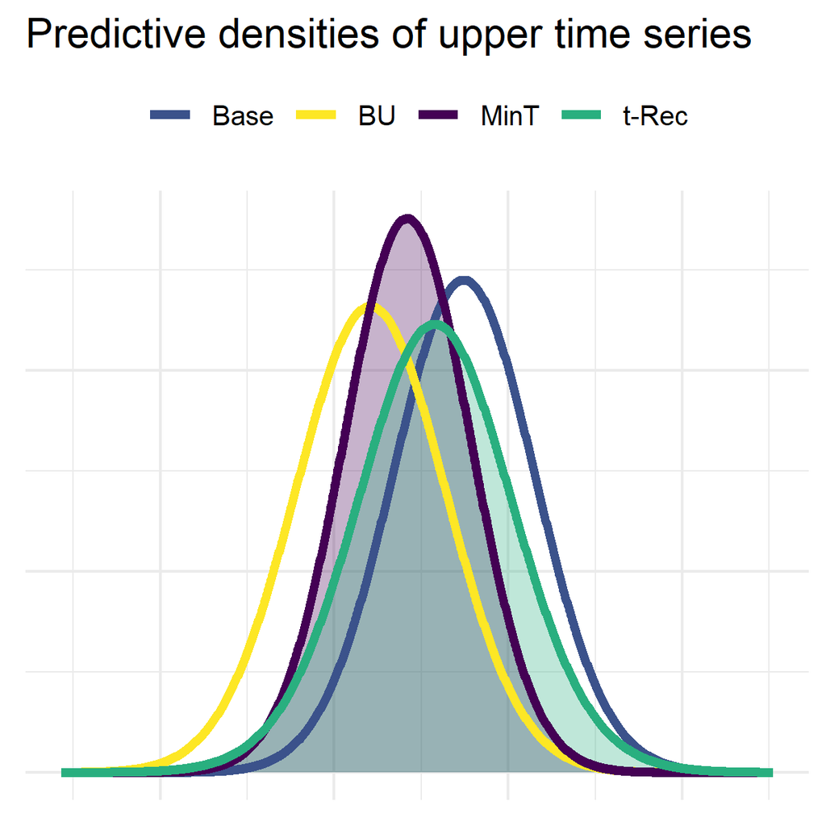

**Figure 2**: Predictive densities of the upper time series obtained with BU (yellow), MinT (purple), t-Rec (green) and Base (blue).

```r
dens_df <- data.frame(
  x = x_vals,
  BU = dens_BU,
  MinT = dens_MinT,
  "t-Rec" = dens_tRec,
  Base = dens_Base,
  check.names = "FALSE"
) %>%
  pivot_longer(cols = -x, names_to = "Method", values_to = "Density")

method_colors <- c(
  "BU" = "#FDE725",
  "MinT" = "#440154",
  "t-Rec" = "#29AF7F",
  "Base" = "#3B528B"
)

ggplot(dens_df, aes(x = x, y = Density, color = Method)) +
  geom_area(
    data = filter(dens_df, Method %in% c("MinT", "t-Rec")),
    aes(fill = Method),
    position = "identity",
    alpha = 0.3,
    color = NA
  ) +
  geom_line(linewidth = 1.5) +
  scale_color_manual(values = method_colors) +
  scale_fill_manual(values = method_colors) +
  guides(fill = "none") +
  labs(
    title = "Predictive densities of upper time series",
    x = "",
    y = ""
  ) +
  theme_minimal(base_size = 12) +
  theme(
    legend.position = "top",
    legend.title = element_blank(),
    axis.title = element_blank(),
    axis.text = element_blank(),
    axis.ticks = element_blank()
  )
```

# References

Zambon, Lorenzo, Arianna Agosto, Paolo Giudici, and Giorgio Corani. 2024. “Properties of the Reconciled Distributions for Gaussian and Count Forecasts.” *International Journal of Forecasting* 40 (4): 1438–48.